# Containerized Big Data Architecture

Charles Wainright

2026-08-07

# Introduction

To execute this pipeline, we deployed a robust multi-node technology stack combining Docker for containerization, a replicated MongoDB NoSQL cluster for high-availability data storage, Apache Spark (PySpark) for distributed data processing, and JupyterLab as an interactive analytical environment. Using this architecture, we established a containerized replica set, performed rigorous data wrangling and type-casting on high-frequency transaction logs, engineered true time-based moving averages over a 30-day window, and queried the distributed datasets to generate and visualize actionable financial insights.

# Environment

## Docker

I used Docker Desktop, which gave me access to both the Docker CLI and a GUI program to manage containers. https://docs.docker.com/desktop/setup/install/windows-install

Then, I installed the Windows Subsystem for Linux to run Docker.

```python
{shell}
wsl --install
```

Finally, I ran the following Docker shell commands (https://github.com/RWaltersMA/mongo-spark-jupyter/tree/master). The commands start new containers, initialize a MongoDB cluster, and then seed the cluster's Stocks database with data from Source.bson.

```python
{shell}
docker-compose up -d --build
```

```python
{shell}
docker-compose exec mongo1 /usr/bin/mongo --eval "if (rs.status()['ok'] == 0) { rsconf = { _id : 'rs0', members: [ { _id : 0, host : 'mongo1:27017', priority: 1.0 }, { _id : 1, host : 'mongo2:27017', priority: 0.5 }, { _id : 2, host : 'mongo3:27017', priority: 0.5 } ] }; rs.initiate(rsconf); } rs.conf();"
```

```python
{shell}
docker-compose exec mongo1 apt-get update
```

```python
{shell}
docker-compose exec mongo1 apt-get install wget
```

```python
{shell}
docker-compose exec mongo1 wget https://github.com/RWaltersMA/mongo-spark-jupyter/raw/master/Source.bson
```

```python
{shell}
docker-compose exec mongo1 /usr/bin/mongorestore Source.bson -h rs0/mongo1:27017,mongo2:27018,mongo3:27019 -d Stocks -c Source --drop
```

```python
{shell}
docker exec -it mongo1 mongorestore --db=Stocks --collection=Source Source.bson
```

### Confirm Docker

I confirmed the health and completeness of my Docker containers with the following shell command which shows me each container in Docker and the container's status.

```python
{shell}
docker ps
```

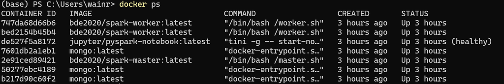

### Confirm Spark

To confirm that Spark was running in my container, I visited `http://localhost:8090/`, which was the port specified for Spark in my `docker-compose.yml` file.

[figure not shown]

### Confirm MongoDB

I confirmed that MongoDB was running and populated with data with the following shell commands. I first queried MongoDB to ask for the name of all databases in my container. Then, I queried my Stocks database to determine how many rows it contained.

```python
{shell}
docker exec -it mongo1 mongosh --eval "show dbs"
docker exec -it mongo1 mongosh Stocks --eval "db.Source.countDocuments()"
```

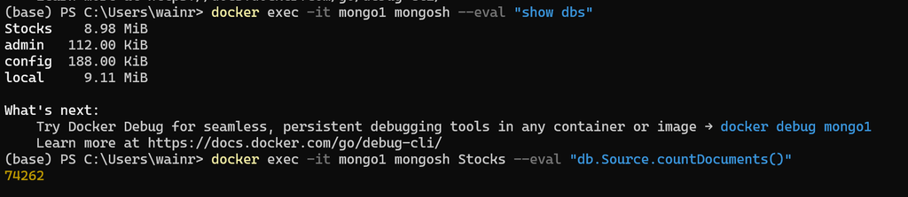

## Python

I spun up a jupyterlab instance in my project's docker container.

```python
{shell}
docker exec -it jupyterlab  /opt/conda/bin/jupyter server list
```

Then I navigated to http://localhost:8888/ in my web browser to begin my jupyter session.

# Data Transformation

## Spark Session

First I connected Spark to my MongoDB via a SparkSession.

```python
# If needed
# !pip install pyspark
```

```python
import plotly.express as px
from pyspark.sql import SparkSession

spark = SparkSession.\
        builder.\
        appName("big_data").\
        master("local[*]").\
        config("spark.mongodb.input.uri", "mongodb://mongo1:27017,mongo2:27018,mongo3:27019/Stocks.Source?replicaSet=rs0").\
        config("spark.mongodb.output.uri", "mongodb://mongo1:27017,mongo2:27018,mongo3:27019/Stocks.Source?replicaSet=rs0").\
        config("spark.jars.packages", "org.mongodb.spark:mongo-spark-connector_2.12:3.0.0").\
        getOrCreate()

df = spark.read.format("mongo").load()
```

Next, I confirmed that my connection was valid by printing the data schema.

```python
df.printSchema()
```

```
root
 |-- _id: struct (nullable = true)
 |    |-- oid: string (nullable = true)
 |-- company: string (nullable = true)
 |-- company_symbol: string (nullable = true)
 |-- movingAverage: double (nullable = true)
 |-- price: double (nullable = true)
 |-- tx_time: timestamp (nullable = true)
```

## Data cleaning in Spark

### Data types

```python
df = df.withColumn('tx_time', df.tx_time.cast('timestamp'))
```

Then, I confirmed that data type cast was successful.

```python
df.printSchema()
```

```
root
 |-- _id: struct (nullable = true)
 |    |-- oid: string (nullable = true)
 |-- company: string (nullable = true)
 |-- company_symbol: string (nullable = true)
 |-- movingAverage: double (nullable = true)
 |-- price: double (nullable = true)
 |-- tx_time: timestamp (nullable = true)
```

### Column renaming

My next task was to rename a column.

```python
df = df.withColumnRenamed('company_name', 'company')
```

I confirmed that my column rename was successful by viewing the top 5 rows.

```python
df.limit(5).toPandas()
```

|  | _id | company | company_symbol | movingAverage | price | tx_time |
| --- | --- | --- | --- | --- | --- | --- |
| 0 | (5f527ac22f6a1552edb3cf44,) | ITCHY ACRE CORPORATION | IAC | 43.385 | 43.38 | 2020-09-04 13:34:58 |
| 1 | (5f527ac22f6a1552edb3cf45,) | HOMELY KIOSK UNLIMITED | HKU | 81.955 | 81.94 | 2020-09-04 13:34:58 |
| 2 | (5f527ac22f6a1552edb3cf46,) | CREEPY GIT HOLDINGS | CGH | 81.975 | 81.99 | 2020-09-04 13:34:58 |
| 3 | (5f527ac22f6a1552edb3cf47,) | FRUSTRATING CHAOS LLC | FCL | 84.550 | 84.58 | 2020-09-04 13:34:58 |
| 4 | (5f527ac22f6a1552edb3cf48,) | LACKADAISICAL SAVAGE PARTNERS | LSP | 41.410 | 41.41 | 2020-09-04 13:34:58 |

### Data Exploration

First, I used `describe()` to generate summary statistics. This method returns a count, min, and max for any data type, and it returns a mean and standard deviation for numeric data.

```python
df.describe().toPandas()
```

|  | summary | company | company_symbol | movingAverage | price |
| --- | --- | --- | --- | --- | --- |
| 0 | count | 74262 | 74262 | 74262 | 74262 |
| 1 | mean | None | None | 60.47715058396868 | 60.477151032829305 |
| 2 | stddev | None | None | 21.598524797763666 | 21.598569729733985 |
| 3 | min | COMBATIVE TOWNSHIP LLC | CGH | 19.99 | 19.98 |
| 4 | max | TRITE JACKFRUIT PARTNERS | TJP | 87.56666666666666 | 87.6 |

## Querying: SELECT

Next, I selected just three columns (company, price, tx_time) and viewed the top 5 rows.

```python
df.select(['company', 'price', 'tx_time']).toPandas().head(5).style \
    .format({"price": "${:.2f}"}) \
    .set_table_styles([
        {"selector": "th", "props": [("background-color", "#f4f4f4"), ("color", "#333"), ("font-weight", "bold"), ("padding", "8px")]},
        {"selector": "td", "props": [("padding", "8px"), ("border-bottom", "1px solid #ddd")]},
        {"selector": "tr:hover", "props": [("background-color", "#f9f9f9")]}
    ]) \
    .hide(axis="index") # Optional: hides the numeric index column for a cleaner look
```

| company | price | tx_time |
| --- | --- | --- |
| ITCHY ACRE CORPORATION | $43.38 | 2020-09-04 13:34:58 |
| HOMELY KIOSK UNLIMITED | $81.94 | 2020-09-04 13:34:58 |
| CREEPY GIT HOLDINGS | $81.99 | 2020-09-04 13:34:58 |
| FRUSTRATING CHAOS LLC | $84.58 | 2020-09-04 13:34:58 |
| LACKADAISICAL SAVAGE PARTNERS | $41.41 | 2020-09-04 13:34:58 |

## Querying: WHERE

I used the `filter()` method to filter the dataset to return only rows where the price was less than or equal to $20.

```python
from pyspark.sql.functions import col, lit, when
df\
.filter(
    (col("price") <= lit(20))
)\
.select('company','price')\
.toPandas()\
.head(5).style \
    .format({"price": "${:.2f}"}) \
    .set_table_styles([
        {"selector": "th", "props": [("background-color", "#f4f4f4"), ("color", "#333"), ("font-weight", "bold"), ("padding", "8px")]},
        {"selector": "td", "props": [("padding", "8px"), ("border-bottom", "1px solid #ddd")]},
        {"selector": "tr:hover", "props": [("background-color", "#f9f9f9")]}
    ]) \
    .hide(axis="index") # Optional: hides the numeric index column for a cleaner look
```

[output not shown]

## Querying: MEAN

I used `groupBy()` and `mean()` to calculate grouped means and then the `orderBy()` method to return the means from highest to lowest average price.

```python
df.select(['company','company_symbol','price'])\
        .groupBy('company','company_symbol')\
        .mean()\
        .orderBy(['avg(price)'], ascending = [False])\
        .toPandas().style \
    .format({"avg(price)": "${:.2f}"}) \
    .set_table_styles([
        {"selector": "th", "props": [("background-color", "#f4f4f4"), ("color", "#333"), ("font-weight", "bold"), ("padding", "8px")]},
        {"selector": "td", "props": [("padding", "8px"), ("border-bottom", "1px solid #ddd")]},
        {"selector": "tr:hover", "props": [("background-color", "#f9f9f9")]}
    ]) \
    .hide(axis="index") # Optional: hides the numeric index column for a cleaner look
```

| company | company_symbol | avg(price) |
| --- | --- | --- |
| FRUSTRATING CHAOS LLC | FCL | $83.95 |
| HOMELY KIOSK UNLIMITED | HKU | $83.30 |
| CREEPY GIT HOLDINGS | CGH | $80.41 |
| GREASY CHAMPION CORPORATION | GCC | $79.61 |
| COMBATIVE TOWNSHIP LLC | CTL | $68.83 |
| FROTHY MIDNIGHT PRODUCTIONS | FMP | $65.32 |
| ITCHY ACRE CORPORATION | IAC | $43.49 |
| LACKADAISICAL SAVAGE PARTNERS | LSP | $41.21 |
| CORNY PRACTITIONER HOLDINGS | CPH | $37.07 |
| TRITE JACKFRUIT PARTNERS | TJP | $21.58 |

## Querying: CASE

Next, I created a column called `recent` and wrote a case statement to populate the column with a 1 when the `tx_time` column was greater than or equal to noon on 2026-06-01.

```python
df.select('company', 'price',
            when(col("tx_time") >= lit("2026-06-01 12:00:00"), 1).otherwise(0).alias('recent')
           ).toPandas()\
.head(5).style \
    .format({"price": "${:.2f}"}) \
    .set_table_styles([
        {"selector": "th", "props": [("background-color", "#f4f4f4"), ("color", "#333"), ("font-weight", "bold"), ("padding", "8px")]},
        {"selector": "td", "props": [("padding", "8px"), ("border-bottom", "1px solid #ddd")]},
        {"selector": "tr:hover", "props": [("background-color", "#f9f9f9")]}
    ]) \
    .hide(axis="index") # Optional: hides the numeric index column for a cleaner look
```

| company | price | recent |
| --- | --- | --- |
| ITCHY ACRE CORPORATION | $43.38 | 0 |
| HOMELY KIOSK UNLIMITED | $81.94 | 0 |
| CREEPY GIT HOLDINGS | $81.99 | 0 |
| FRUSTRATING CHAOS LLC | $84.58 | 0 |
| LACKADAISICAL SAVAGE PARTNERS | $41.41 | 0 |

## Bar Chart

I created a bar chart to show the average price of each of the 10 most-expensive companies.

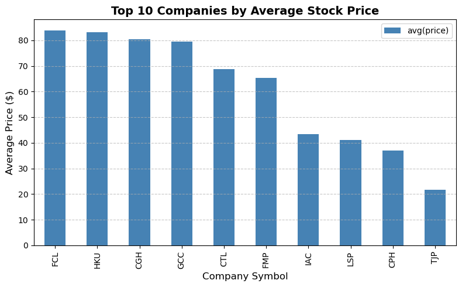

```python
# 1. Perform your PySpark grouping and aggregation
avg_price_df = df.groupBy("company_symbol") \
                 .avg("price") \
                 .orderBy("avg(price)", ascending=False) \
                 .limit(10)

# 2. Convert the Spark DataFrame into a local Pandas DataFrame using .toPandas()
pandas_df = avg_price_df.toPandas()

import matplotlib.pyplot as plt

ax = pandas_df.plot(kind='bar', x='company_symbol', y='avg(price)', color='steelblue', figsize=(8, 5))
plt.title("Top 10 Companies by Average Stock Price", fontsize=14, fontweight='bold')
plt.xlabel("Company Symbol", fontsize=12)
plt.ylabel("Average Price ($)", fontsize=12)
plt.grid(axis='y', linestyle='--', alpha=0.7)
plt.tight_layout()
plt.show()
```

## Moving Average

To evaluate underlying market trends without short-term market noise, I constructed a time-based window frame spanning 30 days of seconds and compute a rolling average of transaction prices grouped by company symbol.

```python
from pyspark.sql import functions as F
from pyspark.sql.window import Window

# Define a time-based window: 30 days behind the current row's timestamp up to the current row
window_30day = Window.partitionBy("company_symbol") \
                     .orderBy(F.col("tx_time").cast("long")) \
                     .rangeBetween(-2592000, 0)

# Calculate the 30-day moving average
movAvg = df.withColumn("movingAverage30day", F.avg("price").over(window_30day))
```

```python
movAvg\
.select('company','tx_time','movingAverage30day')\
.toPandas()\
.head(5).style \
    .format({"movingAverage30day": "${:.2f}"}) \
    .background_gradient(subset=["movingAverage30day"], cmap="Blues") \
    .set_table_styles([
        {"selector": "th", "props": [("background-color", "#2c3e50"), ("color", "white"), ("font-weight", "bold"), ("padding", "8px")]},
        {"selector": "td", "props": [("padding", "8px")]}
    ]) \
    .hide(axis="index")
```

| company | tx_time | movingAverage30day |
| --- | --- | --- |
| CREEPY GIT HOLDINGS | 2020-09-04 13:34:58 | $81.99 |
| CREEPY GIT HOLDINGS | 2020-09-04 13:34:59 | $81.97 |
| CREEPY GIT HOLDINGS | 2020-09-04 13:35:00 | $81.95 |
| CREEPY GIT HOLDINGS | 2020-09-04 13:35:01 | $81.96 |
| CREEPY GIT HOLDINGS | 2020-09-04 13:35:02 | $81.97 |

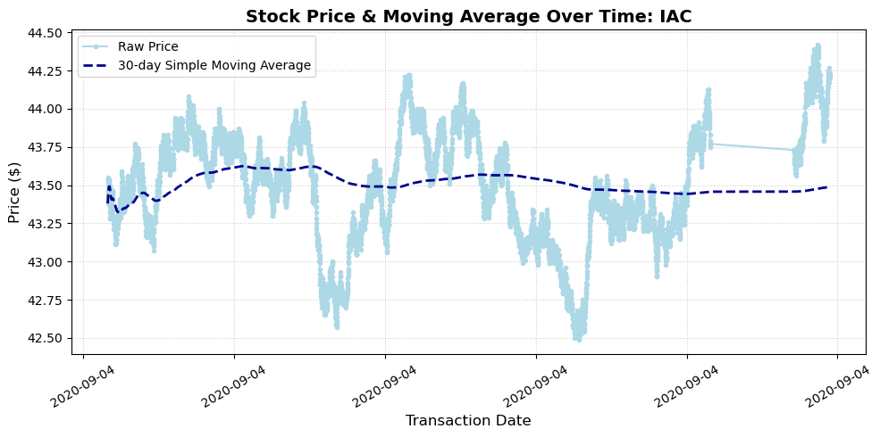

```python
import matplotlib.pyplot as plt
import matplotlib.dates as mdates
import pandas as pd

# 1. Filter and convert to Pandas (ensuring tx_time is recognized as a datetime)
company_df = movAvg.filter(movAvg.company_symbol == "IAC") \
                  .orderBy("tx_time") \
                  .toPandas()

# Ensure the column is explicitly a datetime type
company_df["tx_time"] = pd.to_datetime(company_df["tx_time"])

# 2. Build the Matplotlib figure
plt.figure(figsize=(10, 5))

plt.plot(
    company_df["tx_time"],
    company_df["price"],
    label="Raw Price",
    color="lightblue",
    marker="o",
    markersize=3,
    linestyle="-"
)

plt.plot(
    company_df["tx_time"],
    company_df["movingAverage30day"],
    label="30-day Simple Moving Average",
    color="darkblue",
    linewidth=2,
    linestyle="--"
)

# 3. Format the X-Axis to display as yyyy-mm-dd
plt.gca().xaxis.set_major_formatter(mdates.DateFormatter('%Y-%m-%d'))
# Optional: Adjust locator frequency if labels crowd together (e.g., auto-locate ticks)
plt.gca().xaxis.set_major_locator(mdates.AutoDateLocator())

# Rotate date labels slightly so they don't overlap
plt.xticks(rotation=30)

# 4. Add styling, labels, and legend
plt.title("Stock Price & Moving Average Over Time: IAC", fontsize=14, fontweight="bold")
plt.xlabel("Transaction Date", fontsize=12)
plt.ylabel("Price ($)", fontsize=12)
plt.grid(True, linestyle=":", alpha=0.6)
plt.legend(loc="upper left")
plt.tight_layout()

plt.show()
```

Once I was satisfied that my moving average was correct, I saved the output to the database.

```python
movAvg.write.format("mongo").option("replaceDocument", "true").mode("append").save()
```

# Pipelines and Views

### PySpark Pipelines

```python
pipeline = "[{'$group': {_id:'$company', 'maxprice': {$max:'$price'}}},{$sort:{'maxprice':-1}}]"
aggPipelineDF = spark.read.format("mongo").option("pipeline", pipeline).option("partitioner", "MongoSinglePartitioner").load()
aggPipelineDF.toPandas().head(5)
```

|  | _id | maxprice |
| --- | --- | --- |
| 0 | FRUSTRATING CHAOS LLC | 87.60 |
| 1 | HOMELY KIOSK UNLIMITED | 86.48 |
| 2 | CREEPY GIT HOLDINGS | 83.40 |
| 3 | GREASY CHAMPION CORPORATION | 81.76 |
| 4 | COMBATIVE TOWNSHIP LLC | 72.18 |

### ANSI-compliant SQL

Then I created a view in ANSI-compliant SQL to find records where the moving average was > $43.

```python
movAvg.createOrReplaceTempView("avgs")
sqlDF=spark.sql("SELECT * FROM avgs WHERE movingAverage30day > 43.0")
sqlDF.toPandas().head(5)
```

|  | _id | company | company_symbol | movingAverage | price | tx_time | movingAverage30day |
| --- | --- | --- | --- | --- | --- | --- | --- |
| 0 | (5f527ac22f6a1552edb3cf46,) | CREEPY GIT HOLDINGS | CGH | 81.975000 | 81.99 | 2020-09-04 13:34:58 | 81.990000 |
| 1 | (5f527ac32f6a1552edb3cf50,) | CREEPY GIT HOLDINGS | CGH | 81.953333 | 81.96 | 2020-09-04 13:34:59 | 81.975000 |
| 2 | (5f527ac42f6a1552edb3cf5a,) | CREEPY GIT HOLDINGS | CGH | 81.950000 | 81.91 | 2020-09-04 13:35:00 | 81.953333 |
| 3 | (5f527ac52f6a1552edb3cf64,) | CREEPY GIT HOLDINGS | CGH | 81.963333 | 81.98 | 2020-09-04 13:35:01 | 81.960000 |
| 4 | (5f527ac62f6a1552edb3cf6e,) | CREEPY GIT HOLDINGS | CGH | 82.016667 | 82.00 | 2020-09-04 13:35:02 | 81.968000 |

## Export views

To ensure broad interoperability and support downstream delivery requirements, the final analytical views are exported into CSV, JSON, and Parquet formats.

```python
# CSV
sqlDF.write.csv("sqlview.csv")
aggPipelineDF.write.csv("pipeline.csv")

# JSON
sqlDF.write.save("sqlview.json", format="json")
aggPipelineDF.write.save("pipeline.json", format="json")

# Parquet
sqlDF.write.save("sqlview.parquet", format="parquet")
aggPipelineDF.write.save("pipeline.parquet", format="parquet")
```